# Level of awareness and perceived impact of Artificial Intelligence (AI) in academic activities among graduate students of Visayas State University

Client: Sato Rintaro

Published

September 19, 2026

# 1 Attachments

**Note**

Copies of the Figures presented in this report are available using the links below. All the files can be accessed in the Google drive folder.

1. [Plots](https://drive.google.com/drive/folders/15rtIiUnWZhiMZBlKzb_nDX_mrHBcIV53?usp=sharing)
2. [Google Drive](https://drive.google.com/drive/folders/1OLVnqg6WygvN_kDSxJJ4QS4YXczH9LwL?usp=sharing)

# 2 Objective 1: Describe the socio-demographic characteristics of the respondents.

**CautionInterpretation**

- **Age (Median = 27 years, IQR 25–30)**: Respondents are relatively young, clustered in their mid-to-late 20s. Given their age, they are likely digital natives, which may make them more comfortable with technology and thus more open to AI adoption.
- **Gender (62% Female, 38% Male)**: The sample is female-dominated. Several studies suggest that women may express stronger concerns about academic integrity and ethical risks, while men may report higher frequency of AI use.
- **Program (MS = 64%, others smaller shares)**: The majority are Master of Science students, reflecting VSU’s strength in agriculture and allied sciences. STEM-heavy representation implies higher exposure to data analysis and research tasks where AI tools are directly applicable. Smaller shares in MEd, MM, MAgDev, and PhD provide diversity but may show different adoption patterns.
- **Year Level (54% Second Year, 31% First Year)**: Most respondents are in early-to-mid stages of their graduate journey. First-years may be exploring AI tools for coursework, while second-years are likely integrating them into research. Very few are in advanced years, so findings mainly reflect early adoption rather than long-term reliance.
- **Years in Graduate School (Median = 2 years)**: This aligns with the year-level distribution. Students are still in formative stages of their graduate studies, which means their AI practices are developing rather than fully established.
- **Employment Status (53% full-time students, 47% working students)**: A significant portion balances work with graduate study. Working students may use AI for efficiency and time management, while full-time students may experiment more broadly. This duality could influence usage behavior — practical reliance vs. exploratory adoption.
- **Internet Availability (99%)**: Near-universal access ensures that technological barriers are minimal. This strengthens the validity of findings since lack of connectivity is not a confounding factor.
- **Familiarity with AI (100%)**: All respondents report familiarity, which is remarkable. It indicates AI has already penetrated graduate academic culture at VSU. This sets a strong baseline for analyzing perceptions and usage.
- **Frequency of AI Use (50% often, 31% sometimes, 11% very often, 8% rarely)**: Half of the students use AI often, and another third sometimes — showing widespread integration. Only a small minority rarely use it. This suggests AI is becoming normalized in graduate academic routines, though intensity of use varies.

```r
## descriptive
ai_ms_dta |>
  select(age:ai_tools_used) |>
  select(
    -c(
      weekly_allowance,
      working_experience,
      residence,
      major,
      degree,
      gadget_own,
      gadget_own_type,
      internet_source,
      internet_provider,
      internet_monthly_budget,
      ai_info_source,
      ai_training,
      ai_tools_used
    )
  ) |>
  tbl_summary(
    statistic = list(all_categorical() ~ "{n} ({p}%)"),
    missing = "no",
    label = list(
      age ~ "Age",
      sex ~ "Gender",
      program ~ "Program",
      year_level ~ "Year Level",
      grad_years ~ "Years in Graduate School",
      employment_status ~ "Employment Status",
      internet_availability ~ "Internet
      Availability",
      ai_familiarity ~ "Familiarity with AI",
      ai_use_freq ~ "Frequency of AI Use"
    )
  ) |>
  bold_labels() %>%
  as_kable_extra(linesep = "") %>%
  kable_minimal() %>%
  kable_styling(
    full_width = F,
    fixed_thead = T,
    bootstrap_options = c("striped", "hover", "condensed", "responsive")
  )
```

| Characteristic | N = 216 |
| --- | --- |
| Age | 27.0 (25.0, 30.0) |
| Gender |  |
| Female | 133 (62%) |
| Male | 82 (38%) |
| Program |  |
| MAgDev | 18 (8.5%) |
| MEd | 27 (13%) |
| MM | 16 (7.5%) |
| MS | 137 (64%) |
| PhD | 15 (7.0%) |
| Year Level |  |
| First Year | 67 (31%) |
| Second Year | 116 (54%) |
| Third Year | 25 (12%) |
| Fourth Year | 3 (1.4%) |
| Fifth Year | 4 (1.9%) |
| Years in Graduate School | 2.00 (1.00, 3.00) |
| Employment Status |  |
| Full-time graduate student | 114 (53%) |
| Working full-time graduate student | 53 (25%) |
| Working part-time graduate student | 41 (19%) |
| Others | 7 (3.3%) |
| Internet Availability | 212 (99%) |
| Familiarity with AI | 214 (100%) |
| Frequency of AI Use |  |
| Often | 107 (50%) |
| Rarely | 18 (8.4%) |
| Sometimes | 67 (31%) |
| Very often | 23 (11%) |

<sup>1</sup> Median (Q1, Q3); n (%)

# 3 Objective 2: Determine the level of awareness, perception and AI utilization among graduate students.

### Level of awareness

**CautionInterpretation**

- **Mathematical/Scientific Problem-Solving (56% Agree, 27% Strongly Agree)**: Over 80% of respondents are aware that AI can support problem-solving in technical fields. This shows strong recognition of AI’s utility. Very few disagreed (≈3%).
- **Writing and Language Tasks (52% Agree, 43% Strongly Agree)**: Awareness is extremely high here — nearly 95% acknowledge AI’s role in writing, summarizing, and translation. This is the most universally recognized application, reflecting AI’s visibility in tools like ChatGPT and Grammarly. Only 1% disagreed.
- **Learning Support (48% Agree, 41% Strongly Agree)**: Almost 90% are aware of AI’s potential to help review lessons and anticipate exam questions. This suggests students see AI as a study companion, not just a productivity tool. Neutral responses (8%) indicate some uncertainty about its reliability in this role.
- **Visual Materials/Presentations (55% Agree, 31% Strongly Agree)**: Awareness is also high (≈86%), showing students recognize AI’s potential in creating slides, illustrations, and communication aids. This reflects growing use of generative AI for visuals in academic presentations.
- **Note-Taking and Organizing Study Materials (49% Agree, 29% Strongly Agree)**: Awareness is slightly lower but still strong (≈78%). This suggests students are less exposed to AI tools specifically designed for note-taking/organization compared to writing or problem-solving. Neutral responses (17%) highlight room for growth in this area.

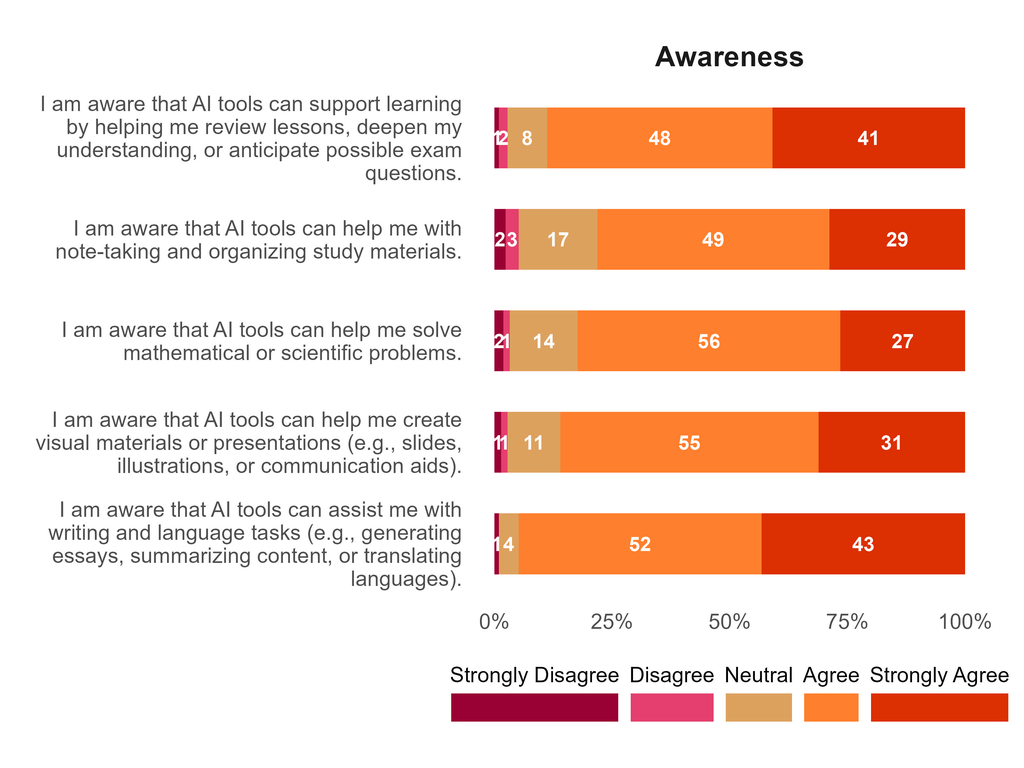

```r
p_ai_awareness <- plot_factor("Awareness", stwidth = 50)

## ggsave
ggsave(
  plot = p_ai_awareness,
  filename = "plot/ai_awareness.jpeg",
  width = 8,
  height = 6,
  dpi = 400,
  unit = "in"
)

## display plot
knitr::include_graphics("plot/ai_awareness.jpeg")
```

# 4 Objective 2: Describe the levels of performance expectancy, effort expectancy, and ethical risk perception as component of overall AI perception.

### Peformance expectancy: Perceived usefulness

**CautionInterpretation**

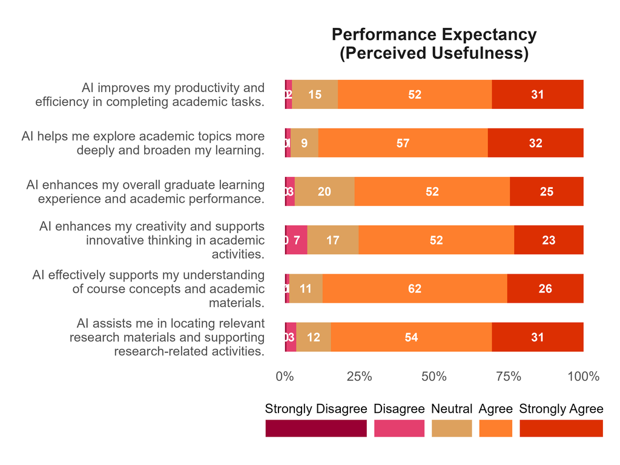

```r
p_performance_expectancy <-
  plot_factor("Performance Expectancy")

## save plot
ggsave(
  plot = p_performance_expectancy,
  filename = "plot/performance_expectancy.jpeg",
  width = 8,
  height = 6,
  dpi = 400,
  unit = "in"
)

## display plot
knitr::include_graphics("plot/performance_expectancy.jpeg")
```

### Effort expectancy: Perceived ease of use

**CautionInterpretation**

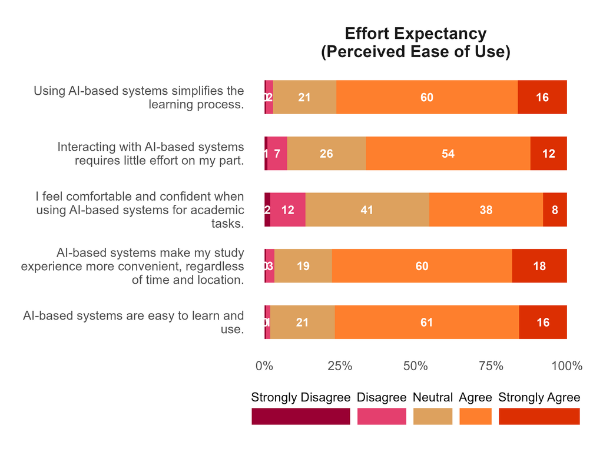

```r
p_effort_expectancy <-
  plot_factor("Effort Expectancy\n(Perceived Ease of Use)")

## save plot
ggsave(
  plot = p_effort_expectancy,
  filename = "plot/effort_expectancy_peou.jpeg",
  width = 8,
  height = 6,
  dpi = 400,
  unit = "in"
)

## display plot
knitr::include_graphics("plot/effort_expectancy_peou.jpeg")
```

### Effort expectancy: Self-efficacy

**CautionInterpretation**

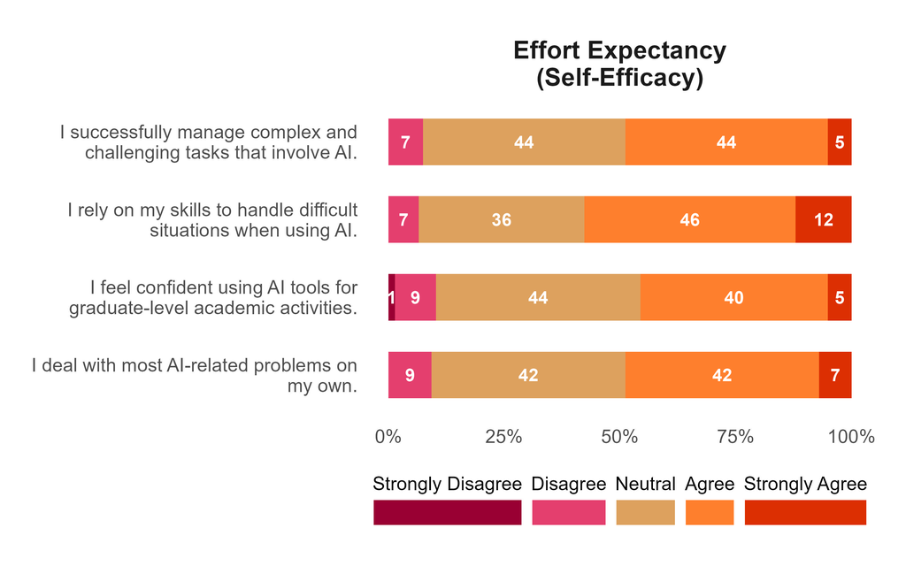

```r
p_effort_expectancy_se <-
  plot_factor("Effort Expectancy\n(Self-Efficacy)")

## save plot
ggsave(
  plot = p_effort_expectancy_se,
  filename = "plot/effort_expectancy_se.jpeg",
  width = 8,
  height = 5,
  dpi = 400,
  unit = "in"
)

## display plot
knitr::include_graphics("plot/effort_expectancy_se.jpeg")
```

### Ethical perceptions: Bias and discrimination

**CautionInterpretation**

**Bias in Training Data (46% Agree, 25% Strongly Agree, 27% Neutral)**: A strong majority (≈71%) recognize that biased training data leads to biased outputs. This shows good awareness of how AI systems inherit limitations from their datasets. The neutral group (27%) suggests some uncertainty about technical mechanisms of bias.

- **Biased Outcomes Disadvantaging Groups (31% Agree, 10% Strongly Agree, 45% Neutral, 14% Disagree)**: Perceptions here are more mixed. While 41% acknowledge biased outcomes, nearly half remain neutral, and 14% disagree. This indicates that while students conceptually understand bias, fewer directly perceive it as disadvantaging specific groups — possibly due to limited exposure to real-world cases.

**Reinforcing Social Inequalities (35% Agree, 9% Strongly Agree, 45% Neutral, 11% Disagree)**: Similar to the previous item, many respondents are undecided (45%). About 44% agree AI can reinforce inequalities, but skepticism (11% disagree) suggests some students may not yet connect AI outputs to broader social impacts.

**Concern About Fairness for Underrepresented Groups (44% Agree, 18% Strongly Agree, 30% Neutral, 8% Disagree)**: A majority (62%) express concern about fairness, showing strong ethical sensitivity. Neutral responses (30%) suggest some students are aware of the issue but not fully convinced of its severity.

- **Regular Evaluation for Fairness (44% Agree, 43% Strongly Agree, 13% Neutral)**: This item received the strongest consensus: 87% support regular evaluation of AI systems for fairness. This indicates students strongly endorse accountability measures and institutional safeguards against bias.

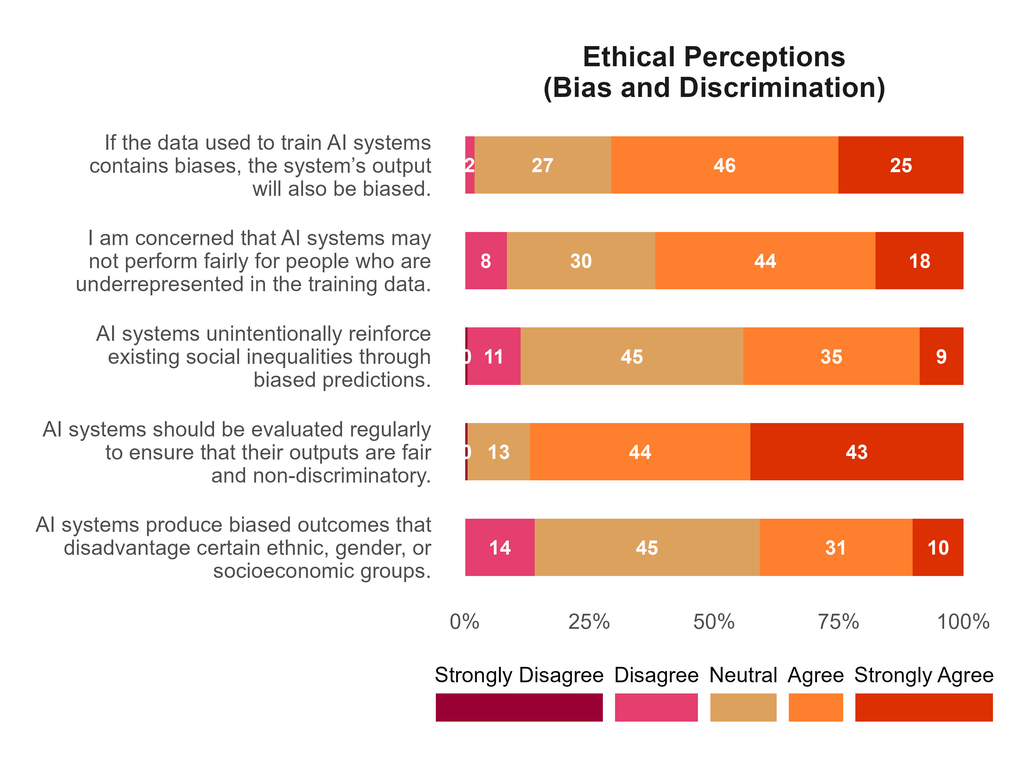

```r
p_ethical_risk_bias <-
  plot_factor("Ethical Perceptions\n(Bias and Discrimination)")

## save plot
ggsave(
  plot = p_ethical_risk_bias,
  filename = "plot/ethical_risk_bias.jpeg",
  width = 8,
  height = 6,
  dpi = 400,
  unit = "in"
)

## display plot
knitr::include_graphics("plot/ethical_risk_bias.jpeg")
```

### Ethical perceptions: Privacy and security

**CautionInterpretation**

**Overall Safety and Reliability (50% Agree, 22% Strongly Agree, 26% Neutral)**: Nearly three-fourths of respondents express concern about AI’s safety and reliability in graduate education. This shows strong awareness of potential risks, though a quarter remain neutral, indicating uncertainty or limited direct experience with failures.

**Security Compared to Other Educational Technologies (39% Agree, 11% Strongly Agree, 44% Neutral, 7% Disagree)**: Perceptions are mixed. Half believe AI tools may be less secure, but almost as many are neutral. This suggests students are unsure how AI compares to traditional educational technologies in terms of security.

**Collection of Excessive Personal Information (43% Agree, 31% Strongly Agree, 22% Neutral)**: A majority (≈74%) worry about excessive data collection. This highlights strong privacy concerns, reflecting broader debates about surveillance and data ethics in AI.

**Unauthorized Use or Sharing of Personal Information (43% Agree, 29% Strongly Agree, 25% Neutral)**: Similarly, about 72% are concerned about unauthorized data use. This indicates students are highly sensitive to privacy risks, even if they haven’t directly experienced them.

**Failures or Malfunctions Affecting Learning (47% Agree, 30% Strongly Agree, 20% Neutral)**: Over three-fourths worry that technical malfunctions could disrupt learning. This shows students recognize AI’s fragility and potential to negatively impact academic activities if systems fail.

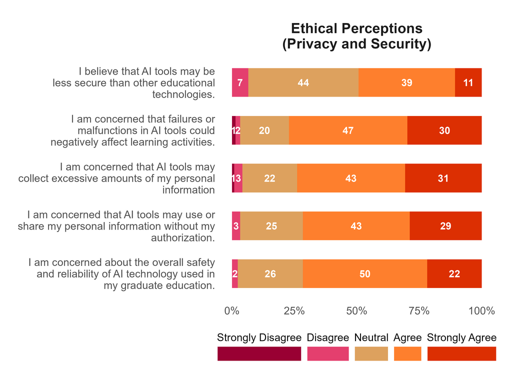

```r
p_ethical_risk_privacy <-
  plot_factor("Ethical Perceptions\n(Privacy and Security)")

## save plot
ggsave(
  plot = p_ethical_risk_privacy,
  filename = "plot/ethical_risk_privacy.jpeg",
  width = 8,
  height = 6,
  dpi = 400,
  unit = "in"
)

## display plot
knitr::include_graphics("plot/ethical_risk_privacy.jpeg")
```

### Ethical perceptions: Transparency

**CautionInterpretation**

**Difficulty Trusting Without Explanations (50% Agree, 21% Strongly Agree, 22% Neutral)**: About 71% of respondents say they cannot fully trust AI tools unless outputs are explained. This highlights transparency as a prerequisite for trust. The neutral group (22%) suggests some students are undecided but cautious.

- **Need for Greater Transparency (52% Agree, 30% Strongly Agree, 17% Neutral)**: Over 80% emphasize transparency as necessary for confidence in AI outcomes. This is one of the strongest consensus points, showing students want clarity in how AI supports learning and research.

**AI Tools Often Lack Transparency (39% Agree, 22% Strongly Agree, 32% Neutral, 7% Disagree)**: A majority (61%) perceive AI as lacking transparency. The large neutral cluster (32%) indicates that while many recognize the issue, others may not have enough experience to judge.

- **Outputs Not Clearly Explained (44% Agree, 14% Strongly Agree, 31% Neutral, 10% Disagree)**: More than half agree AI outputs are not well explained, which makes it difficult to understand their influence on academic work. Neutral responses (31%) again show uncertainty or limited exposure.

**Insufficient Explanations Overall (40% Agree, 16% Strongly Agree, 35% Neutral, 9% Disagree)**: A majority (56%) believe AI tools fail to provide sufficient explanations. The 35% neutral group suggests students are aware of the issue but not strongly convinced.

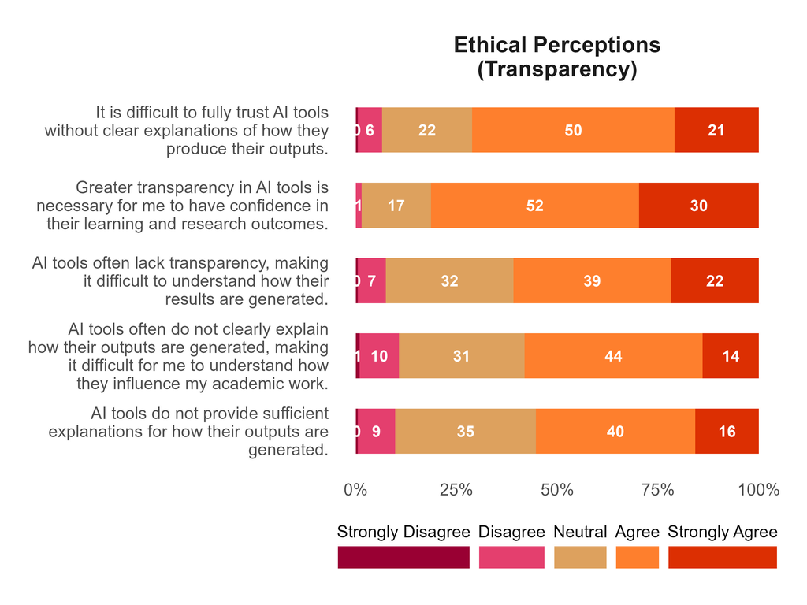

```r
p_ethical_risk_transparency <-
  plot_factor("Ethical Perceptions\n(Transparency)")

## save plot
ggsave(
  plot = p_ethical_risk_transparency,
  filename = "plot/ethical_risk_transparency.jpeg",
  width = 8,
  height = 6,
  dpi = 400,
  unit = "in"
)

## display plot
knitr::include_graphics("plot/ethical_risk_transparency.jpeg")
```

### Ethical perceptions: Over-reliance on AI

**CautionInterpretation**

- **Becoming Overly Dependent (35% Agree, 25% Strongly Agree, 26% Neutral, 12% Disagree)**: About 60% of respondents worry about dependence on AI in learning. The neutral group (26%) suggests some uncertainty, while 12% disagree, showing a minority who feel confident they can balance AI use.
- **Relying Too Much in Research/Writing (36% Agree, 21% Strongly Agree, 28% Neutral, 12% Disagree)**: A majority (57%) express concern about over-reliance in academic writing and research. This reflects awareness of risks to originality and integrity. Neutral responses (28%) indicate some students are undecided about the extent of this risk.
- **Weakening Critical/Independent Thinking (41% Agree, 29% Strongly Agree, 19% Neutral, 10% Disagree)**: About 70% believe excessive AI use could erode critical thinking skills. This is one of the strongest concerns, showing students value independent intellectual development.
- **Limiting Original Ideas and Analytical Abilities (41% Agree, 32% Strongly Agree, 17% Neutral, 10% Disagree)**: Nearly three-fourths worry that heavy reliance on AI could stifle creativity and analytical growth. This is the most strongly endorsed concern, highlighting students’ desire to preserve originality in graduate-level work.
- **Reducing Autonomy in Learning/Decision-Making (39% Agree, 31% Strongly Agree, 18% Neutral, 12% Disagree)**: About 70% fear AI may reduce autonomy. This shows students are aware of the subtle risk of outsourcing judgment to AI, even if they benefit from its convenience.

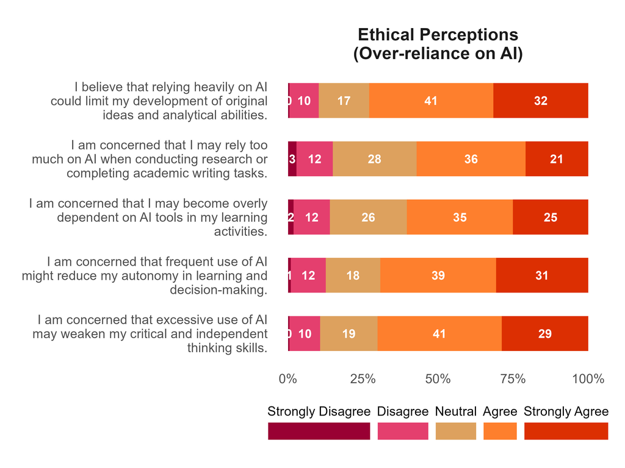

```r
p_ethical_risk_overreliance <-
  plot_factor("Ethical Perceptions\n(Over-reliance on AI)")

## save plot
ggsave(
  plot = p_ethical_risk_overreliance,
  filename = "plot/ethical_risk_overreliance.jpeg",
  width = 8,
  height = 6,
  dpi = 400,
  unit = "in"
)

## display plot
knitr::include_graphics("plot/ethical_risk_overreliance.jpeg")
```

### Ethical perceptions: Equity and access

**CautionInterpretation**

- **Skills Requirement (36% Agree, 14% Strongly Agree, 33% Neutral, 13% Disagree)**: Half of respondents recognize that AI use requires skills not all graduate students possess. This highlights digital literacy gaps as a barrier to equitable adoption. The large neutral group (33%) suggests some uncertainty about how significant these skill gaps are.
- **Inequities in Research Productivity (45% Agree, 9% Strongly Agree, 33% Neutral, 12% Disagree)**: More than half believe unequal access to AI tools creates disparities in research productivity. This shows awareness that AI can amplify existing inequalities in academic output.
- **Inequities in Academic Performance (36% Agree, 11% Strongly Agree, 36% Neutral, 14% Disagree)**: Perceptions are mixed. While nearly half see AI as contributing to performance inequities, an equally large neutral cluster (36%) suggests uncertainty. This may reflect differences in exposure to AI across disciplines.
- **Inequities in Academic Achievement (38% Agree, 10% Strongly Agree, 36% Neutral, 12% Disagree)**: Similar to performance, about half acknowledge achievement gaps linked to AI access. Neutral responses again indicate that many students are undecided or cautious in attributing inequities directly to AI.
- **Lack of Access to AI Tools (39% Agree, 13% Strongly Agree, 32% Neutral, 13% Disagree)**: A majority (52%) believe inequities arise because some students lack access to AI tools. This underscores infrastructure and resource disparities as a key ethical concern.

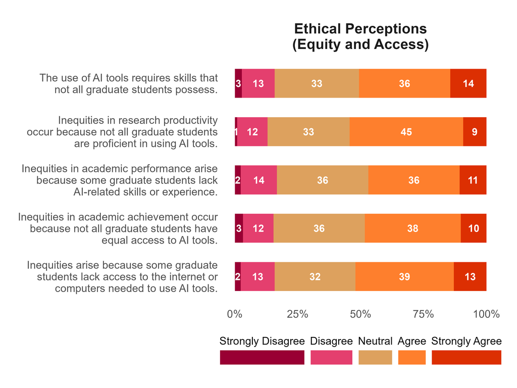

```r
p_ethical_risk_equity <-
  plot_factor("Ethical Perceptions\n(Equity and Access)")

## save plot
ggsave(
  plot = p_ethical_risk_equity,
  filename = "plot/ethical_risk_equity.jpeg",
  width = 8,
  height = 6,
  dpi = 400,
  unit = "in"
)

## display plot
knitr::include_graphics("plot/ethical_risk_equity.jpeg")
```

### Peformance expectancy: Perceived usefulness

**CautionInterpretation**

- **Understanding Course Concepts (62% Agree, 26% Strongly Agree, 11% Neutral)**: Nearly nine in ten respondents affirm that AI supports their comprehension of academic materials. This shows AI is widely seen as a learning aid, with very minimal disagreement (≈1%).
- **Exploring Topics More Deeply (57% Agree, 32% Strongly Agree, 9% Neutral)**: This item received one of the strongest endorsements: almost 90% believe AI broadens their learning horizons. It highlights AI’s role in expanding perspectives and deepening engagement.
- **Enhancing Creativity and Innovation (52% Agree, 23% Strongly Agree, 17% Neutral)**: About three-fourths feel AI stimulates creativity and supports innovative thinking. This suggests students perceive AI not just as a tool for efficiency but as a catalyst for new ideas.
- **Improving Productivity and Efficiency (52% Agree, 31% Strongly Agree, 15% Neutral)**: Over 80% agree AI boosts efficiency in completing academic tasks. This is a core benefit, aligning with global findings that AI saves time and streamlines work.
- **Assisting in Research Materials (54% Agree, 31% Strongly Agree, 12% Neutral)**: Research support is highly valued, with 85% positive responses. This underscores AI’s role in literature search and data-related tasks, which are central to graduate-level work.
- **Enhancing Overall Graduate Learning Experience (52% Agree, 25% Strongly Agree, 20% Neutral)**: About three-fourths believe AI improves their graduate journey. However, one-fifth remain neutral, showing some caution about its overall impact.

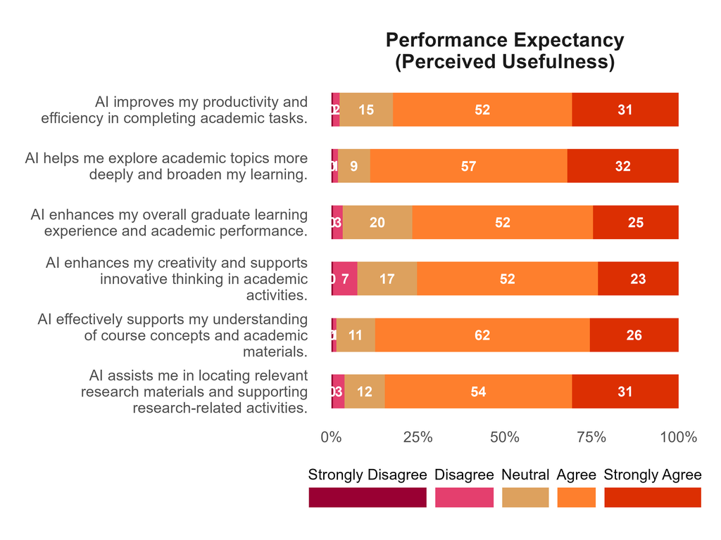

```r
p_performance_expectancy <-
  plot_factor("Performance Expectancy")

## save plot
ggsave(
  plot = p_performance_expectancy,
  filename = "plot/performance_expectancy.jpeg",
  width = 8,
  height = 6,
  dpi = 400,
  unit = "in"
)

## display plot
knitr::include_graphics("plot/performance_expectancy.jpeg")
```

# 5 Objective 3: Analyze the relationship of socio-demographic variables with AI awareness, perception and utilization.

## 5.1 Factor Analysis

Before running Partial Least Squares Structural Equation Modeling (PLS-SEM), it is important to know which survey items (i.e., questions items) belong to which latent constructs (i.e., factors). PLS-SEM assumes that the measurement model or the way items form factors is already well-defined. If we assign items incorrectly, the SEM results may be misleading.

Exploratory Factor Analysis (EFA) examines how items naturally group together based on correlations, revealing the underlying factors. In other words, EFA helps us discover the “building blocks” of the model by showing which items should serve as indicators for each construct.

A scree plot with parallel analysis (Figure below) is a tool used in Exploratory Factor Analysis (EFA) to check if how many possible factors we can extract.

### 5.1.1 Parallel analysis

In running the parallel analysis, we first separate the survey items into three blocks: (1) lower-order constructs (Awareness, Performance Expectancy, and Use of AI), (2) higher-order construct Effort Expectancy (with sub-dimensions Perceived Ease of Use and Self-Efficacy), and (3) higher-order construct Ethical Risk Perceptions (with sub-dimensions Bias and Discrimination, Privacy and Security, Transparency, Over-reliance on AI, and Equity and Access). Each block is analyzed separately to determine the number of factors to extract.

For lower-order constructs, the parallel analysis suggests extracting 3 factors. For the higher-order construct Effort Expectancy, 2 factors are suggested. For the higher-order construct Ethical Risk Perceptions, 5 factors are suggested.

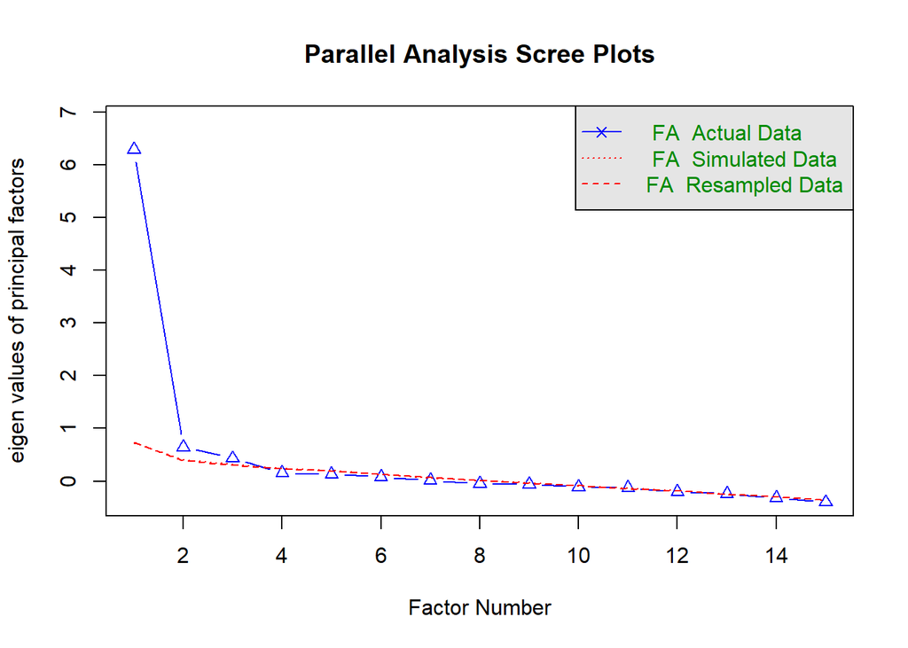

```
Parallel analysis suggests that the number of factors =  3  and the number of components =  NA
```

```r
## parallel analysis for lower order constructs
## expected factor: 3

block1 <- sem_ai_ms_dta |> select(a1:a5, pe1:pe6, ai_use1:ai_use4)

fa.parallel(block1, fm = "ml", fa = "fa")
```

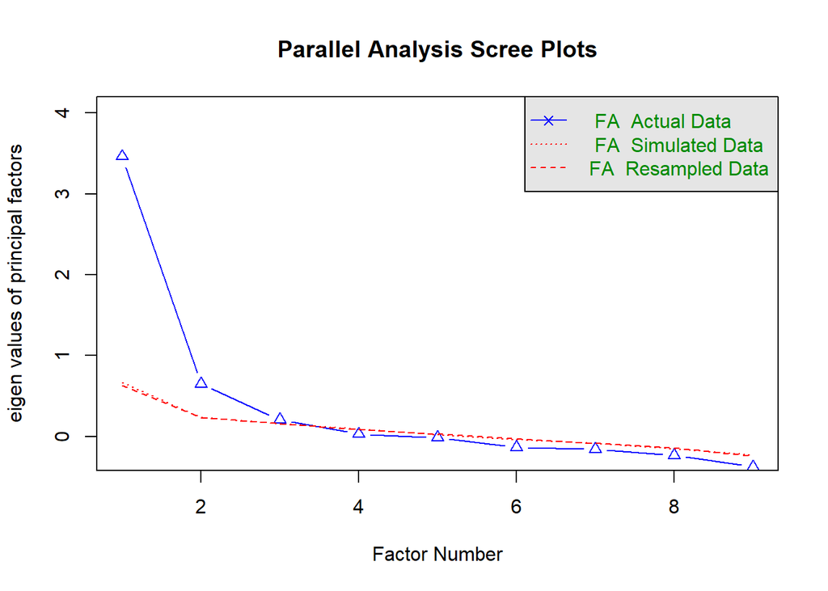

```
Parallel analysis suggests that the number of factors =  2  and the number of components =  NA
```

```r
## parallel analysis for higher order construct effort expectancy

## expected factor: 2
block2 <- sem_ai_ms_dta |> select(ee_peu1:ee_peu5, ee_se1:ee_se4)

fa.parallel(block2, fm = "ml", fa = "fa")
```

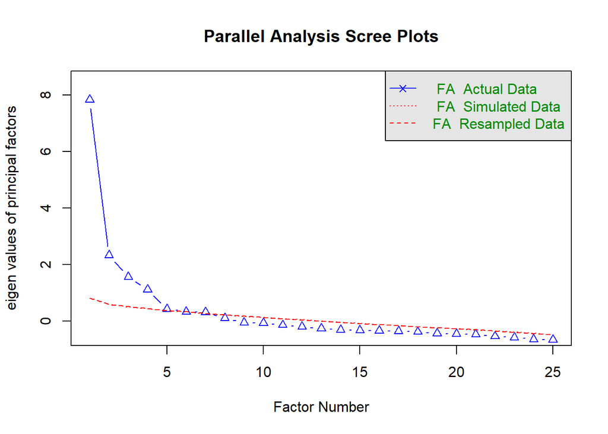

```
Parallel analysis suggests that the number of factors =  5  and the number of components =  NA
```

```r
## parallel analysis for higher order construct ethical perceptions

## expected factor: 5
block3 <- sem_ai_ms_dta |>
  select(
    ee_bd1:ee_bd5,
    ee_ps1:ee_ps5,
    ee_t1:ee_t5,
    ee_oe1:ee_oe5,
    ee_ea1:ee_ea5
  )

fa.parallel(block3, fm = "ml", fa = "fa")
```

### 5.1.2 Factor extraction

Below is the facto extraction for the three blocks of survey items. The factor loadings indicate how strongly each item is associated with the extracted factors. Items with loadings above 0.3 are considered meaningful indicators of their respective factors.

The first factor extraction is for the lower-order constructs (Awareness, Performance Expectancy, and Use of AI), which suggests 3 factors. For Awareness, items a1, a2, a4, and a5 load strongly on Factor 1. While a3 has a relatively low loading on Factor 1, it loads moderately on Factor 2. For Performance Expectancy, items pe1 through pe6 load strongly on Factor 2. For Use of AI, items ai_use1 through ai_use4 load strongly on Factor 3.

```r
fa_block1 <- fa(block1, nfactors = 3, fm = "ml", rotate = "oblimin")

print(fa_block1$loadings, cutoff = 0.3, sort = TRUE)
```

```
Loadings:
        ML2    ML3    ML1
pe1      0.865
pe2      0.880
pe3      0.664
pe4      0.507
pe5      0.534
ai_use2         0.674
ai_use3         0.712
ai_use4         0.590
a4                     0.770
a5                     0.572
a1                     0.432
a2                     0.400
a3       0.357         0.340
pe6      0.465
ai_use1         0.417

                 ML2   ML3   ML1
SS loadings    2.982 1.737 1.586
Proportion Var 0.199 0.116 0.106
Cumulative Var 0.199 0.315 0.420
```

```r
fa_block2 <- fa(block2, nfactors = 2, fm = "ml", rotate = "oblimin")

print(fa_block2$loadings, cutoff = 0.3, sort = TRUE)
```

```
Loadings:
        ML1    ML2
ee_peu1  0.737
ee_peu2  0.550
ee_peu3  0.767
ee_peu4  0.650
ee_peu5  0.808
ee_se1          0.596
ee_se2          0.818
ee_se3          0.556
ee_se4   0.415

                 ML1   ML2
SS loadings    2.735 1.462
Proportion Var 0.304 0.162
Cumulative Var 0.304 0.466
```

```r
fa_block3 <- fa(block3, nfactors = 4, fm = "ml", rotate = "oblimin")
print(fa_block3$loadings, cutoff = 0.3, sort = TRUE)
```

```
Loadings:
       ML2    ML4    ML1    ML3
ee_oe1  0.607
ee_oe2  0.618
ee_oe3  0.917
ee_oe4  0.897
ee_oe5  0.880
ee_t1          0.655
ee_t2          0.761
ee_t3          0.879
ee_t5          0.810
ee_ea1                0.647
ee_ea2                0.819
ee_ea3                0.864
ee_ea4                0.832
ee_ea5                0.711
ee_bd1                       0.538
ee_bd2                       0.846
ee_bd3                       0.903
ee_bd4                       0.641
ee_bd5                       0.345
ee_ps1         0.301
ee_ps2         0.333
ee_ps3         0.346         0.319
ee_ps4         0.346
ee_ps5         0.419
ee_t4          0.440

                 ML2   ML4   ML1   ML3
SS loadings    3.503 3.296 3.238 2.736
Proportion Var 0.140 0.132 0.130 0.109
Cumulative Var 0.140 0.272 0.401 0.511
```

## 5.2 PLS-SEM

```r
measurement_model <- constructs(
  composite("Awareness", multi_items("a", c(1, 2, 4, 5))),
  composite("PerformanceExpectancy", multi_items("pe", 1:5)),
  composite("UseOfAI", multi_items("ai_use", 2:4)),

  # First-order sub-dimensions of Effort Expectancy
  composite("PerceivedEaseOfUse", multi_items("ee_peu", 1:5)),
  composite("SelfEfficacy", multi_items("ee_se", 1:3)),

  # First-order sub-dimensions of Ethical Risk Perceptions
  composite("BiasDiscrimination", multi_items("ee_bd", 1:5)),
  composite(
    "PrivacyTransparency",
    c(paste0("ee_ps", 1:5), paste0("ee_t", 1:5))
  ),
  composite("Overreliance", multi_items("ee_oe", 1:5)),
  composite("EquityAccess", multi_items("ee_ea", 1:5)),

  # Higher-order constructs (repeated-indicators approach)
  composite(
    "EffortExpectancy",
    c(
      multi_items("ee_peu", 1:5),
      multi_items("ee_se", 1:3)
    )
  ),
  composite(
    "EthicalRiskPerceptions",
    c(
      multi_items("ee_bd", 1:5),
      paste0("ee_ps", 1:5),
      paste0("ee_t", 1:5),
      multi_items("ee_oe", 1:5),
      multi_items("ee_ea", 1:5)
    )
  )
)

# plot(measurement_model, title = "Measurement Model Loadings")
```

### 5.2.1 Structural model

In estimating the PLS-SEM model, we first define the measurement model, which specifies how observed survey items (indicators) relate to their underlying latent constructs (factors). The constructs are defined as composites, with each composite representing a latent variable measured by multiple indicators.

In the structural model, we specify the hypothesized relationships between the latent constructs. For example, we hypothesize that Awareness influences Effort Expectancy, Ethical Risk Perceptions, and Performance Expectancy, which in turn affect the Use of AI.

```r
structural_model <- relationships(
  paths(
    from = "Awareness",
    to = c(
      "EffortExpectancy",
      "EthicalRiskPerceptions",
      "PerformanceExpectancy"
    )
  ),
  paths(from = "EffortExpectancy", to = "UseOfAI"),
  paths(from = "EthicalRiskPerceptions", to = "UseOfAI"),
  paths(from = "PerformanceExpectancy", to = "UseOfAI")
)

pls_model <- estimate_pls(
  data = sem_ai_ms_dta,
  measurement_model = measurement_model,
  structural_model = structural_model,
  missing = mean_replacement,
  missing_value = NA
)


plot(pls_model, title = "Structural Model Path Coefficients")
```

[interactive chart not shown]

```r
summary_pls <- summary(pls_model)
# DT::datatable(summary_pls$paths |> round(3))
```

### 5.2.2 Bootstrapped estimates and direct effects

The table below presents the bootstrapped estimates of the path coefficients, which provide a measure of the stability and reliability of the estimated relationships in the structural model. Bootstrapping involves repeatedly resampling the data and estimating the model to generate a distribution of path coefficients, allowing us to assess their significance and confidence intervals.

**CautionInterpretation**

```r
set.seed(7391)
boot_pls <- bootstrap_model(
  seminr_model = pls_model,
  nboot = 1000,
  cores = parallel::detectCores() - 1
)


summary_boot <- summary(boot_pls)
DT::datatable(summary_boot$bootstrapped_paths |> round(3))
```

|  | Original Est. | Bootstrap Mean | Bootstrap SD | T Stat. | 2.5% CI | 97.5% CI | Bootstrap P Val |
| --- | --- | --- | --- | --- | --- | --- | --- |
| Awareness -&gt; EffortExpectancy | 0.608 | 0.614 | 0.056 | 10.88 | 0.497 | 0.717 | 0 |
| Awareness -&gt; EthicalRiskPerceptions | 0.27 | 0.304 | 0.052 | 5.179 | 0.196 | 0.405 | 0 |
| Awareness -&gt; PerformanceExpectancy | 0.679 | 0.681 | 0.054 | 12.61 | 0.569 | 0.781 | 0 |
| EffortExpectancy -&gt; UseOfAI | 0.396 | 0.392 | 0.069 | 5.731 | 0.256 | 0.525 | 0 |
| EthicalRiskPerceptions -&gt; UseOfAI | 0.211 | 0.232 | 0.055 | 3.876 | 0.125 | 0.338 | 0 |
| PerformanceExpectancy -&gt; UseOfAI | 0.22 | 0.217 | 0.076 | 2.875 | 0.062 | 0.354 | 0.006 |

```r
plot(boot_pls, title = "Bootstrapped Path Coefficients")
```

[interactive chart not shown]

### 5.2.3 Indirect effects

Below are the results for the indirect effects, which capture the mediating influence of Effort Expectancy, Ethical Risk Perceptions, and Performance Expectancy on the relationship between Awareness and Use of AI. The indirect effects quantify how much of the effect of Awareness on Use of AI is transmitted through these mediators.

**CautionInterpretation**

- **Awareness → Effort Expectancy → Use of AI (β = 0.241, p < .001)**: This is the strongest of the three specific indirect paths (95% CI [0.148, 0.341]). Awareness increases students’ perceived ease of use and self-efficacy with AI, which in turn drives greater use of AI tools — this is the primary mechanism through which awareness translates into actual AI use.
- **Awareness → Performance Expectancy → Use of AI (β = 0.149, p = .006)**: Awareness also promotes AI use by shaping students’ perception of AI’s usefulness for academic tasks (95% CI [0.044, 0.250]), though this path’s confidence interval is comparatively closer to zero and the effect is roughly two-thirds the size of the effort-expectancy route.
- **Awareness → Ethical Risk Perceptions → Use of AI (β = 0.057, p < .001)**: This is the weakest specific indirect path (95% CI [0.036, 0.113]), though still statistically significant. Ethical risk perception is a comparatively minor conduit between awareness and AI use — consistent with the earlier finding that awareness explains little variance in ethical risk perceptions (R² = 7.3%).
- **Total indirect effect of Awareness on Use of AI (β = 0.447, p < .001)**: Summing across all three mediators, awareness has a substantial overall indirect effect on AI use (95% CI [0.373, 0.539]). Effort expectancy accounts for over half of this total indirect effect, underscoring that making AI feel easy and manageable to use is the dominant pathway linking awareness to actual adoption in this sample.

```r
## add the specific indirect effects to the summary table
specific_indirect_effects <- rbind(
  specific_effect_significance(
    boot_seminr_model = boot_pls,
    from = "Awareness",
    through = "EffortExpectancy",
    to = "UseOfAI"
  ),
  specific_effect_significance(
    boot_seminr_model = boot_pls,
    from = "Awareness",
    through = "EthicalRiskPerceptions",
    to = "UseOfAI"
  ),
  specific_effect_significance(
    boot_seminr_model = boot_pls,
    from = "Awareness",
    through = "PerformanceExpectancy",
    to = "UseOfAI"
  )
)

DT::datatable(specific_indirect_effects |> round(3))
```

|  | Original Est. | Bootstrap Mean | Bootstrap SD | T Stat. | 2.5% CI | 97.5% CI | Bootstrap P Val |
| --- | --- | --- | --- | --- | --- | --- | --- |
| Awareness-&gt;EffortExpectancy-&gt;UseOfAI | 0.241 | 0.241 | 0.05 | 4.807 | 0.148 | 0.341 | 0 |
| Awareness-&gt;EthicalRiskPerceptions-&gt;UseOfAI | 0.057 | 0.07 | 0.019 | 3.006 | 0.036 | 0.113 | 0 |
| Awareness-&gt;PerformanceExpectancy-&gt;UseOfAI | 0.149 | 0.147 | 0.052 | 2.887 | 0.044 | 0.25 | 0.006 |

### 5.2.4 Total effects

Whereas the direct effects capture only the immediate path between two constructs and the indirect effects capture mediated paths, total effects sum these together to represent the overall influence of one construct on another, combining both direct and any mediated routes.

**CautionInterpretation**

- **Awareness → Use of AI (β = 0.447, p < .001)**: Awareness has no direct path to Use of AI in this model, so this total effect is entirely indirect — it is fully accounted for by the three mediators (Effort Expectancy, Ethical Risk Perceptions, and Performance Expectancy). The 95% CI [0.373, 0.539] indicates a robust overall influence: greater awareness of AI meaningfully translates into greater use, but only through how it shapes students’ perceptions of ease of use, usefulness, and ethical risk.
- **Awareness → Effort Expectancy, Ethical Risk Perceptions, and Performance Expectancy**: Since these three constructs have no other predictors in the model, their total effects (0.608, 0.270, and 0.679, respectively) are identical to their direct effects reported earlier — there is no additional mediated component to add.
- **Effort Expectancy, Ethical Risk Perceptions, and Performance Expectancy → Use of AI**: Likewise, these three mediators have only a direct path to Use of AI (0.396, 0.211, and 0.220, respectively), so their total effects equal their direct effects.
- **Overall pattern**: Awareness is the only construct in the model whose influence on the final outcome (Use of AI) is entirely indirect, working through the three mediating constructs rather than by a direct route. This supports interpreting the model as a fully mediated pathway from awareness to AI use.

```r
total_effects <- summary_pls$total_effects
DT::datatable(total_effects |> round(3))
```

|  | Awareness | EffortExpectancy | EthicalRiskPerceptions | PerformanceExpectancy | UseOfAI |
| --- | --- | --- | --- | --- | --- |
| Awareness | 0 | 0.608 | 0.27 | 0.679 | 0.447 |
| EffortExpectancy | 0 | 0 | 0 | 0 | 0.396 |
| EthicalRiskPerceptions | 0 | 0 | 0 | 0 | 0.211 |
| PerformanceExpectancy | 0 | 0 | 0 | 0 | 0.22 |
| UseOfAI | 0 | 0 | 0 | 0 | 0 |

## 5.3 Reliability test

**CautionInterpretation**

```r
DT::datatable(summary_pls$reliability |> round(3))
```

|  | alpha | rhoA | rhoC | AVE |
| --- | --- | --- | --- | --- |
| Awareness | 0.78 | 0.782 | 0.859 | 0.603 |
| EffortExpectancy | 0.822 | 0.863 | 0.863 | 0.451 |
| EthicalRiskPerceptions | 0.917 | 0.927 | 0.917 | 0.312 |
| PerformanceExpectancy | 0.88 | 0.887 | 0.912 | 0.675 |
| UseOfAI | 0.701 | 0.719 | 0.833 | 0.626 |

## 5.4 Validity test: Fornell-Larcker criterion

**CautionInterpretation**

- **Discriminant validity is met for all constructs**: For every construct, the square root of AVE (diagonal values, ranging from 0.558 for Ethical Risk Perceptions to 0.822 for Performance Expectancy) exceeds its correlations with all other constructs. This satisfies the Fornell-Larcker criterion, indicating each construct shares more variance with its own indicators than with any other construct in the model.
- **Effort Expectancy and Performance Expectancy show the smallest margin (0.672 vs. correlations of 0.608 and 0.657)**: While the criterion is still met, the gap between Effort Expectancy’s diagonal value and its correlation with Awareness (0.608) and Performance Expectancy (0.657) is comparatively narrow. Combined with its low AVE noted in the reliability test, this suggests Effort Expectancy’s discriminant validity is less comfortably established than the other constructs and is worth monitoring, e.g., with an HTMT check, which is generally considered a stricter and more reliable test than Fornell-Larcker.
- **Ethical Risk Perceptions is clearly distinct from the other constructs**: Its correlations with Awareness (0.270), Effort Expectancy (0.206), Performance Expectancy (0.160), and Use of AI (0.328) are all modest, and its diagonal value (0.558) comfortably exceeds each. This supports treating ethical risk perception as conceptually and empirically separate from the technology-acceptance constructs (awareness, effort/performance expectancy) in this model.
- **Caveat**: The Fornell-Larcker criterion is a commonly used but comparatively lenient test of discriminant validity, and it can fail to detect discriminant validity problems that HTMT would catch, especially for constructs already flagged with low AVE (Effort Expectancy, Ethical Risk Perceptions). These results should be corroborated with an HTMT ratio check before treating discriminant validity as fully established.

```r
DT::datatable(summary_pls$validity$fl_criteria |> round(3))
```

|  | Awareness | EffortExpectancy | EthicalRiskPerceptions | PerformanceExpectancy | UseOfAI |
| --- | --- | --- | --- | --- | --- |
| Awareness | 0.776 |  |  |  |  |
| EffortExpectancy | 0.608 | 0.672 |  |  |  |
| EthicalRiskPerceptions | 0.27 | 0.206 | 0.558 |  |  |
| PerformanceExpectancy | 0.679 | 0.657 | 0.16 | 0.822 |  |
| UseOfAI | 0.479 | 0.584 | 0.328 | 0.513 | 0.791 |

## 5.5 Structural model fit indices

**CautionInterpretation**

- **Collinearity is not a concern (VIF < 2)**: All predictors of Use of AI — Effort Expectancy (1.792), Ethical Risk Perceptions (1.045), and Performance Expectancy (1.761) — fall well below the 3.3 threshold, indicating the path coefficients are not distorted by multicollinearity among predictors.
- **Awareness has a large effect on Effort and Performance Expectancy, but a small effect on Ethical Risk Perceptions (f²)**: Awareness explains a substantial share of variance in Effort Expectancy (f² = 0.586) and Performance Expectancy (f² = 0.858), both large effects. Its effect on Ethical Risk Perceptions is comparatively small (f² = 0.079), consistent with the low R² (7.3%) observed for that construct — awareness alone does little to shape how strongly students perceive ethical risks of AI.
- **Effort Expectancy contributes most to explaining AI use, though all effects are modest (f²)**: Among the three predictors of Use of AI, Effort Expectancy has the largest incremental contribution (f² = 0.143, small-to-medium), followed by Ethical Risk Perceptions (f² = 0.069) and Performance Expectancy (f² = 0.046), both small effects.
- **Model comparison via information criteria**: AIC and BIC are reported per endogenous construct rather than for the model overall, since PLS-SEM is variance-based and does not yield a single covariance-based fit statistic (e.g., CFI, RMSEA). These values are most useful for comparing alternative specifications of the same construct’s predictors rather than judging absolute fit.

```r
DT::datatable(
  summary_pls$vif_antecedents$UseOfAI |> as.data.frame() |> round(3)
)
```

|  | summary_pls$vif_antecedents$UseOfAI |
| --- | --- |
| EffortExpectancy | 1.792 |
| EthicalRiskPerceptions | 1.045 |
| PerformanceExpectancy | 1.761 |

```r
DT::datatable(summary_pls$fSquare |> round(3))
```

|  | Awareness | EffortExpectancy | EthicalRiskPerceptions | PerformanceExpectancy | UseOfAI |
| --- | --- | --- | --- | --- | --- |
| Awareness | 0 | 0.586 | 0.079 | 0.858 | 0 |
| EffortExpectancy | 0 | 0 | 0 | 0 | 0.143 |
| EthicalRiskPerceptions | 0 | 0 | 0 | 0 | 0.069 |
| PerformanceExpectancy | 0 | 0 | 0 | 0 | 0.046 |
| UseOfAI | 0 | 0 | 0 | 0 | 0 |

```r
DT::datatable(summary_pls$it_criteria |> round(3))
```

|  | EffortExpectancy | EthicalRiskPerceptions | PerformanceExpectancy | UseOfAI |
| --- | --- | --- | --- | --- |
| AIC | -96.674 | -13.367 | -130.766 | -108.122 |
| BIC | -89.923 | -6.617 | -124.015 | -94.621 |